# Flow-dependent predictability

refer to https://stefansiegert.net/forecast_postprocessing/2016/09/11/flow-dependent-uncertainty.html.

This note illustrates the flow-dependent predictability in the 2011 paper Uncertainty in weather and climate prediction by Slingo and Palmer. They use the system of nonlinear differential equations commonly known as the Lorenz63 system to illustrate the fact that, depending on today’s weather, tomorrow’s weather can be more or less predictable.

The [Lorenz63 system](http://journals.ametsoc.org/doi/abs/10.1175/1520-0469%281963%29020%3C0130%3ADNF%3E2.0.CO%3B2) is described by three variables XX, YY, and ZZ whose evolution is described by the differential equations:

```r
library(deSolve)

#differential equations of the Lorenz'63 system
l63 = function(t, state, parms=NA) {
  list(c(
    10 * (state['Y'] - state['X']),
    -1 * state['X'] * state['Z'] + 28 * state['X'] - state['Y'],
    state['X'] * state['Y'] - 8 / 3 * state['Z'])
  )
}

lorenz63 = deSolve::ode(y=c(X=8,Y=13,Z=18), times=seq(0,100,0.01), func=l63)
lorenz63
```

| time | X | Y | Z |
| --- | --- | --- | --- |
| 0.00 | 8.000000000 | 13.000000000 | 18.000000 |
| 0.01 | 8.508145460 | 13.667117154 | 18.612785 |
| 0.02 | 9.030801884 | 14.319122795 | 19.334482 |
| 0.03 | 9.564408006 | 14.940146962 | 20.168704 |
| 0.04 | 10.104104991 | 15.511868585 | 21.116550 |
| 0.05 | 10.643641661 | 16.013803852 | 22.175744 |
| 0.06 | 11.175336421 | 16.423883385 | 23.339766 |
| 0.07 | 11.690094196 | 16.719337678 | 24.597017 |
| 0.08 | 12.177533729 | 16.877968009 | 25.930184 |
| 0.09 | 12.626241258 | 16.879744106 | 27.315967 |

[output cut: 990 more lines]

Below I plot a long trajectory of the system in the XX-ZZ plane - this 2d representation of the Lorenz63 system is often called the butterfly attractor.

I have chosen two points in the XX-ZZ plane to illustrate flow-dependent predictability similar to Slingo and Palmer (2011). Solutions that are initially close to the point (12, 21) remain close for a period of time. On the other hand, solutions that are initially close to the point (-9.5, 36) quickly diverge from each other over the same period of time.

```r
# plot the butterfly attractor
plot(lorenz63[,'X'], lorenz63[,'Z'],type='l', col='#99999999')

# stable
x0 = 12
z0 = 21
inds = which( abs(lorenz63[,'X'] - x0) < 0.5 & abs(lorenz63[, 'Z'] - z0) < 0.5 )
for (i in inds) {
  lines(lorenz63[i:(i+60), 'X'], lorenz63[i:(i+60), 'Z'], col='blue')
}
```

```r
points(x0, z0, pch=21, cex=2, lwd=3)

# unstable
x0 = -9.5
z0 = 36
inds = which( abs(lorenz63[,'X'] - x0) < 0.5 & abs(lorenz63[, 'Z'] - z0) < 0.5 )
for (i in inds) {
  lines(lorenz63[i:(i+60), 'X'], lorenz63[i:(i+60), 'Z'], col='orange', lwd=2)
}
```

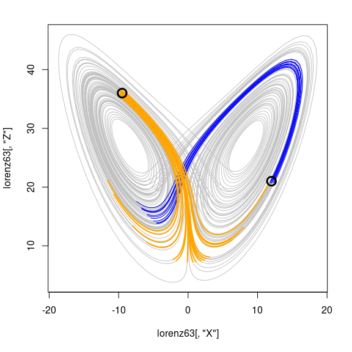

```r
points(x0, z0, pch=21, cex=2, lwd=3)
```

So if you live in Lorenz63 world, and today’s weather is X=12X=12 and Z=21Z=21, you know that a small measurement error will not effect the short-term forecast too much. On the other hand, if the weather today is X=−9.5X=−9.5 and Z=36Z=36, the forecast is extremely sensitive. A small error in measuring the initial state can produce a forecast that is far far away from the truth.

This is what [Lorenz](http://onlinelibrary.wiley.com/doi/10.1111/j.2153-3490.1969.tb00444.x/abstract) meant when he wrote

> one flap of a sea gull’s wings would forever change the future course of the weather

The sea gull was later replaced by a butterfly, probably because “butterfly effect” sounds nicer than “sea gull effect”.

The essence of flow-dependent predictability is that depending on what the weather is like today, the flap of the wing can change the course of the weather slowly or quickly.

The goal of ensemble weather forecasting is to estimate how sensitive today’s weather forecast is to uncertainties in the initial conditions. Due to flow-dependent predictability, the weather on any given day can be more or less predictable.